# Spotify project on Fleetwood Mac

Author

Emilia Schmidt

# Welcome to my Spotify Project on Fleetwood Mac

## Who is Fleetwood Mac?

Fleetwood Mac, is a British/American pop-rock band formed in London in 1967. The name stemmed from the drummer Mick Fleetwood and bassist John McvVie. They have created over 100 songs over the years. Their most famous songs include “Dreams” and “The Chain”.

[figure not shown]

All members of Fleetwood Mac

## Best Quote/Song Lyric:

> “*Time makes you bolder”*

> **- Fleetwood Mac**

## Top 5 Albums:

1. Rumours
2. Fleetwood Mac
3. Tusk
4. Furture Games
5. Say You Will

## My Favorite Song:

[Gypsy by Fleetwood Mac](https://www.youtube.com/watch?v=mwgg1Pu6cNg)

[video not shown]

# Data Analysis:

### Installing packages:

I first installed some packages in order for me to do the analysis. I then extracted the data using the `spotifyr` package, and stored it in a data folder I named myData.

```r
#I loaded the library for ggplot 2, dplyr, and readr in order to complete my project
library(ggplot2)
library(dplyr)
library(readr)
#I saved all the data on Fleetwood Mac as myData to make accessibility easier
myData <- read.csv("Fleetwood Mac.csv")
```

### Sorting the data and filtering out unnecessary songs:

I saw in the data that there were multiple songs with “Take” ect., therefore I decided to filter out these songs and not include them in the data set. I also saw that there were multiple versions of the same song which were recorded on different dates so I decided to get rid of these too. Finally, I also tried deleted the album Transmission Impossible because this was only a re-release of songs that had already been released.

```r
#I filtered the songs to only include the ones without "Take" and numbers from "0-9" in them
filtered_songs <- myData[
  !grepl("Take", myData$track_name, ignore.case = TRUE) &
  !grepl("[0-9]", myData$track_name) &
  !grepl("Transmission Impossible", myData$album_name),
]
```

## Getting a feel for the data:

I think that Fleetwood Mac has a large variance in how energetic their songs are. Therefore, I decided to take a look if this is actually true and how this translates to the loudness of the songs.

### Most energetic songs:

Then I wanted to take a look at the most lively songs. And out of all the albums the five most lively songs are shown below.

```r
#To see what I was doing I decided to look at the 5 most livly songs
filtered_songs |> slice_max(energy, n=5) |> dplyr::select(track_name, album_name, album_release_year, energy) |> knitr::kable(digits = 2)
```

| track_name | album_name | album_release_year | energy |
| --- | --- | --- | --- |
| Everybody Finds Out | Say You Will | 2003 | 0.96 |
| Murrow Turning over in His Grave | Say You Will | 2003 | 0.96 |
| Destiny Rules | Say You Will | 2003 | 0.92 |
| Bleed to Love Her | Say You Will | 2003 | 0.91 |
| Running Through the Garden | Say You Will | 2003 | 0.91 |

You can see that all the most energetic songs were in the same album. I think these results are very accurate as these songs and especially this albums has a lot of upbeat percussion instruments! The energy reached its highest in the song “Everybody Finds Out” with an energy level of 0.96.

### Least energetic songs:

Here are the songs that are least energetic.

```r
#I also decided to look at the 5 least energetic songs
filtered_songs |> slice_min(energy, n=5) |> dplyr::select(track_name, album_name, album_release_year, energy) |> knitr::kable(digits = 2)
```

| track_name | album_name | album_release_year | energy |
| --- | --- | --- | --- |
| Trying So Hard to Forget | Mr. Wonderful | 1968 | 0.03 |
| Thoughts on a Grey Day | Bare Trees | 1972 | 0.09 |
| You’re So Evil | Fleetwood Mac | 1968 | 0.09 |
| The Way I Feel | Mystery to Me | 1973 | 0.11 |
| The Second Time | Behind the Mask | 1990 | 0.12 |

These songs were all part of different albums which I though interesting, as I would have thought that bare trees was the least energetic album.

### Longest songs:

I also looked at the songs that lasted the longest because I know that the songs in the 70’s usually last longer but I still wanted to see if these theory proved to be true. These were the results:

```r
#And finally I decided to look at the 3 longest songs
filtered_songs |> slice_max(duration_ms, n=3) |> dplyr::select(track_name, album_name, album_release_year, duration_ms) |> knitr::kable(digits = 2)
```

| track_name | album_name | album_release_year | duration_ms |
| --- | --- | --- | --- |
| Future Games | Future Games | 1971 | 499115 |
| Sands of Time | Future Games | 1971 | 440662 |
| These Strange Times | Time | 1995 | 428146 |

The longest song was 8 minutes long! So, indeed the songs were longer than 3 minutes.

### Selecting Albums:

After doing this I decided that there were too many albums in the data set. Therefore, I filtered for 5 that I liked best. I stored the data under selected_albums. This now enabled me to use all the data from the albums as well as only the selected ones.

```r
#After playing around with the data, I decided to select only 5 albums to analyse
selected_albums <- filtered_songs |>
  filter(album_name %in% c(
    "Fleetwood Mac",
    "Say You Will",
    "Future Games",
    "Penguin",
    "Tusk (Deluxe Edition)"
  ))
```

# Presenting the Data:

## Scatterplots: Loudness vs. Energy

My first analysis looked at the loudness and the energy of the different albums. Here you could see that the albums are very clustered by song. The overall loudness was also low with some albums being more energetic than others.

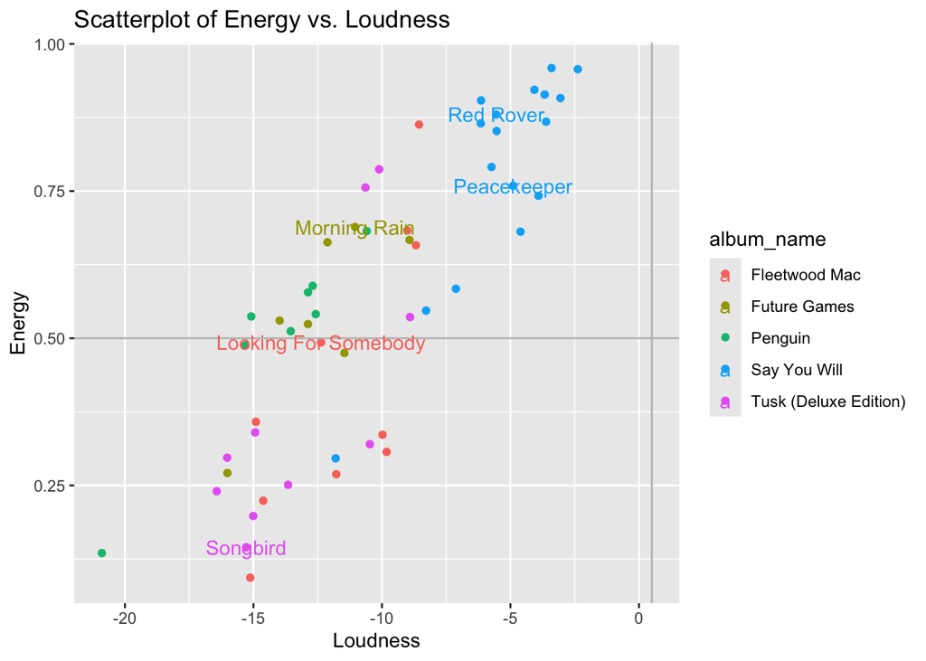

```r
#Here I decided to create names of the songs in different albums and made them show up on the scatterplot
subgroup <- myData |>
  filter(track_name %in% c(
    "Looking For Somebody",
    "Morning Rain",
    "No Place To Go",
    "Red Rover",
    "Peacekeeper",
    "Songbird"))

ggplot(selected_albums, aes(x = loudness, y = energy, color = album_name)) + geom_point()+
  geom_hline(yintercept = 0.5, color="grey") +
  geom_vline(xintercept = 0.5, color="grey")+
  labs(title="Scatterplot of Energy vs. Loudness", x="Loudness", y="Energy")+
  geom_text(data=subgroup, aes(label=track_name))
```

```r
#I also decided to label all the axis and give it a title
```

Next I looked at the loudness and the energy of the different songs in all the albums. The curve shows a upward facing slope. This means that the louder the song the more energy the song had. All the songs were in the lower range for loudness, suggesting that even if songs were energetic they were quiet.

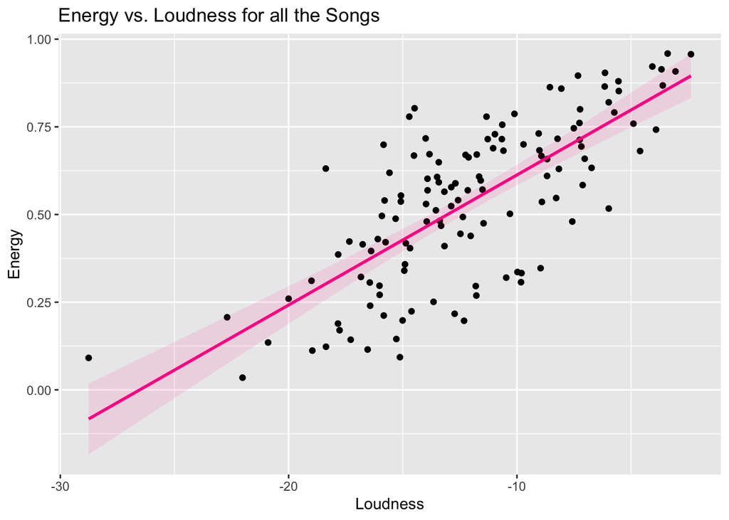

```r
#Here I created a scattergraph with all the filtered songs included
ggplot(filtered_songs, aes(x = loudness, y = energy)) +
  geom_point() +
  geom_smooth(method = "lm", colour = "#FF1493", alpha = 0.1, fill ="#FF1493")+
  labs(title="Energy vs. Loudness for all the Songs", x="Loudness", y="Energy")
```

## Boxplot for the Danceability for different albums:

Then I decide to look at danceability for the different albums and found that they all had a similar level, however the album Tusk had the highest danceability. The Fleetwood Mac album had the one with the greatest range of danceable songs. So, if you would like to have a great mix of songs to either dance or just listen to, this album would be the best for you. The biggest outliers were in the “Say You Will” album, which we found to be the one with the most energetic songs but here you can see the album does not have the highest dancability, which is surprising.

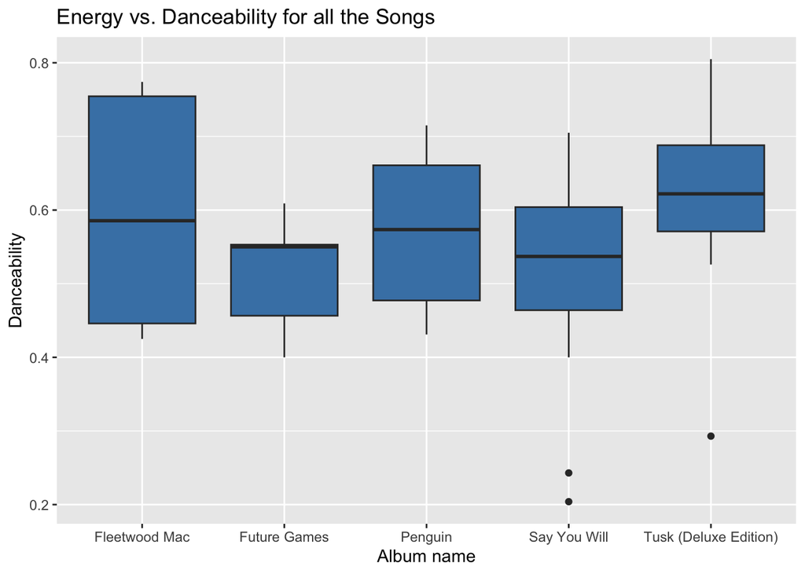

```r
#The Boxplot for the different danceable songs in the albums selected
ggplot(selected_albums, aes(x=album_name, y=danceability))+
  geom_boxplot(fill= "#4682B4")+
  labs(x="Album name", y="Danceability", title="Energy vs. Danceability for all the Songs")
```

## Histograms for the Tempo of different Albums:

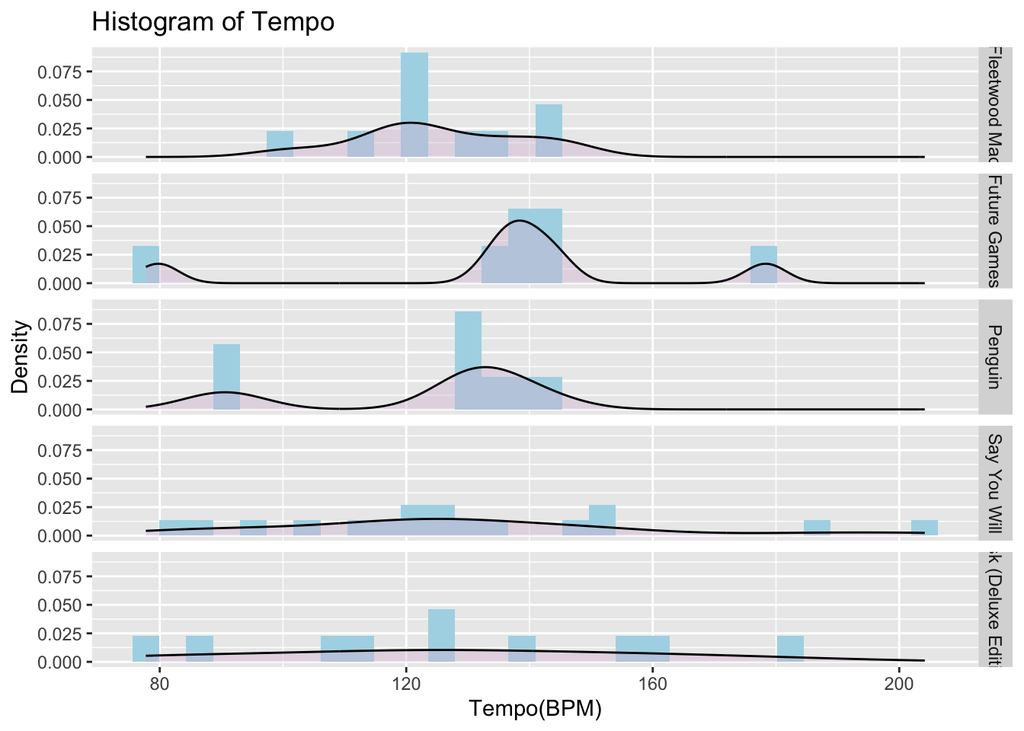

```r
#
ggplot(selected_albums, aes(x=tempo))+
 geom_histogram(aes(y=..density..), fill="lightblue")+
 geom_density(fill="#D8BFD8", alpha= 0.4)+
 facet_grid(album_name ~ .)+
 labs(title="Histogram of Tempo", x="Tempo(BPM)", y="Density")
```

# Final words of wisdom:

The band Fleetwood Mac has a large range of energetic and danceacable songs. However, it does not mean that one album alone is more danceable than others. They have a good variety of different songs and I would recommend all to listen to them even if they are a little older!

Therefore…….

> **Let yourself lay back within your dreams!**

> - Fleetwood Mac